# Bin50 frozen-program rook adjacency sensitivity audit

Author

Codex

Published

August 22, 2026

```powershell
# Run from the repository root after the analysis-approval gate.
powershell.exe -NoProfile -ExecutionPolicy Bypass `
  -File scripts/383_render_rook_adjacency_report.ps1
```

## Scope and approved conclusion

This sensitivity audit retained the completed five frozen gene panels and all existing Bin50 program scores. It changed only the spatial graph from the historical queen eight-neighborhood to a rook four-neighborhood with an actual orthogonal coordinate step of 50 native units (25 µm). It did not rerun differential expression, GSEA, scoring, panel selection, or any additional spatial analysis.

The user approved the following final QC status:

```r
status_table <- data.frame(
  qc_domain = c(
    "BIN-SCORE ALIGNMENT",
    "COORDINATE ORIENTATION",
    "SPATIAL ADJACENCY"
  ),
  status = c(
    status[["BIN-SCORE ALIGNMENT"]],
    status[["COORDINATE ORIENTATION"]],
    status[["SPATIAL ADJACENCY"]]
  )
)
knitr::kable(status_table, format = "html")
```

| qc_domain | status |
| --- | --- |
| BIN-SCORE ALIGNMENT | PASS |
| COORDINATE ORIENTATION | PASS |
| SPATIAL ADJACENCY | PASS |

## Frozen sensitivity definition

- Existing within-sample program z-scores were read without modification.
- High-score Bin50 threshold remained `z >= 1`.
- A hotspot remained a connected high-score component with at least 4 Bin50.
- Bin area remained 0.000625 mm².
- Rook edges required an orthogonal 50-native-unit displacement and membership in the same patient and the same authoritative source-tissue component.
- Moran’s I used 999 within-source-component permutations and the original fixed seed scheme.
- Patient disease models and the formal BH family of 75 tests were unchanged; only Moran’s I, hotspot count, and largest hotspot area were substituted by their rook values.

## Patient-level queen versus rook metrics

The table reports the median across 21 patients for each program and metric.

```r
metric_display <- metric_summary
numeric_columns <- c(
  "queen_patient_median",
  "rook_patient_median",
  "median_delta_rook_minus_queen",
  "maximum_absolute_patient_delta"
)
metric_display[numeric_columns] <- lapply(
  metric_display[numeric_columns],
  function(value) sprintf("%.6f", value)
)
knitr::kable(metric_display, format = "html")
```

| program | metric | queen_patient_median | rook_patient_median | median_delta_rook_minus_queen | maximum_absolute_patient_delta |
| --- | --- | --- | --- | --- | --- |
| Fibroblast_ECM | morans_i | 0.176722 | 0.183076 | 0.009614 | 0.030727 |
| Fibroblast_ECM | hotspot_count | 44.000000 | 35.000000 | -1.000000 | 42.000000 |
| Fibroblast_ECM | largest_hotspot_area_mm2 | 0.041250 | 0.021250 | -0.016875 | 0.110000 |
| B_core | morans_i | 0.017012 | 0.019986 | 0.000006 | 0.035705 |
| B_core | hotspot_count | 2.000000 | 1.000000 | -1.000000 | 34.000000 |
| B_core | largest_hotspot_area_mm2 | 0.003125 | 0.002500 | -0.001250 | 0.066875 |
| Cilia_Axoneme | morans_i | 0.186740 | 0.202740 | 0.017686 | 0.043530 |
| Cilia_Axoneme | hotspot_count | 30.000000 | 28.000000 | -2.000000 | 60.000000 |
| Cilia_Axoneme | largest_hotspot_area_mm2 | 0.051875 | 0.024375 | -0.022500 | 0.217500 |
| AT2 | morans_i | 0.225072 | 0.246998 | 0.014010 | 0.027830 |
| AT2 | hotspot_count | 42.000000 | 34.000000 | -3.000000 | 37.000000 |
| AT2 | largest_hotspot_area_mm2 | 0.058125 | 0.023125 | -0.022500 | 0.255625 |
| TNF_NFkB_Oxidative_Stress | morans_i | 0.194514 | 0.203901 | 0.009621 | 0.044138 |
| TNF_NFkB_Oxidative_Stress | hotspot_count | 44.000000 | 45.000000 | 0.000000 | 122.000000 |
| TNF_NFkB_Oxidative_Stress | largest_hotspot_area_mm2 | 0.055000 | 0.023125 | -0.018750 | 0.210625 |

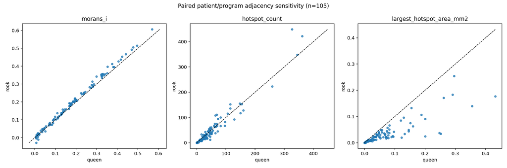

Rook adjacency generally reduced hotspot size because diagonal links no longer merged high-score components. Moran’s I remained close to the queen result. These numerical changes did not alter any formal program-level spatial QC call.

## Formal spatial reproducibility calls

The original formal gate requires a positive BH-significant Moran result, at least one hotspot, and multigene support in the high-score area. At least 11 of 21 coherent samples and at least two per chip are required.

```r
program_display <- program_summary[c(
  "program",
  "queen_positive_moran_sample_n",
  "rook_positive_moran_sample_n",
  "queen_hotspot_present_sample_n",
  "rook_hotspot_present_sample_n",
  "queen_coherent_spatial_sample_n",
  "rook_coherent_spatial_sample_n",
  "queen_spatial_qc_pass",
  "rook_spatial_qc_pass",
  "spatial_qc_conclusion_changed"
)]
knitr::kable(program_display, format = "html")
```

| program | queen_positive_moran_sample_n | rook_positive_moran_sample_n | queen_hotspot_present_sample_n | rook_hotspot_present_sample_n | queen_coherent_spatial_sample_n | rook_coherent_spatial_sample_n | queen_spatial_qc_pass | rook_spatial_qc_pass | spatial_qc_conclusion_changed |
| --- | --- | --- | --- | --- | --- | --- | --- | --- | --- |
| Fibroblast_ECM | 21 | 21 | 21 | 21 | 13 | 13 | True | True | False |
| B_core | 13 | 12 | 15 | 13 | 0 | 0 | False | False | False |
| Cilia_Axoneme | 21 | 21 | 21 | 21 | 16 | 16 | True | True | False |
| AT2 | 21 | 21 | 21 | 21 | 20 | 20 | True | True | False |
| TNF_NFkB_Oxidative_Stress | 21 | 21 | 21 | 21 | 16 | 16 | True | True | False |

`B_core` was the only borderline structure program: positive Moran samples changed from 13 to 12 and hotspot-present samples from 15 to 13. Its coherent multigene support was zero under both graph definitions, so its formal spatial QC remained failed. The other four program calls remained passed.

## Patient-level disease tests

```r
disease_summary <- data.frame(
  item = c(
    "Adjacency-related tests",
    "Queen BH-FDR < 0.05",
    "Rook BH-FDR < 0.05",
    "FDR conclusion changes",
    "Nonsignificant effect-direction changes"
  ),
  value = c(
    nrow(disease_compare),
    sum(disease_compare$BH_FDR_all_75_tests_queen < 0.05),
    sum(disease_compare$BH_FDR_all_75_tests_rook < 0.05),
    sum(tolower(disease_compare$FDR05_conclusion_changed) == "true"),
    sum(tolower(disease_compare$effect_direction_changed) == "true")
  )
)
knitr::kable(disease_summary, format = "html")
```

| item | value |
| --- | --- |
| Adjacency-related tests | 45 |
| Queen BH-FDR < 0.05 | 0 |
| Rook BH-FDR < 0.05 | 0 |
| FDR conclusion changes | 0 |
| Nonsignificant effect-direction changes | 8 |

No adjacency-related patient disease conclusion changed. Direction changes were confined to very small, strongly nonsignificant effects and are not used for biological interpretation.

## Coordinate and orientation validation figures

The all-21 contact sheet shows the authoritative H5AD outline, current keyed coordinates, and their overlay for every patient.

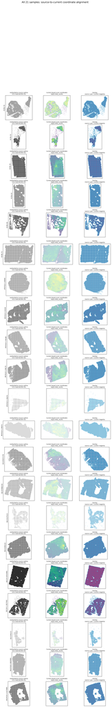

### K8 source-versus-current gene maps

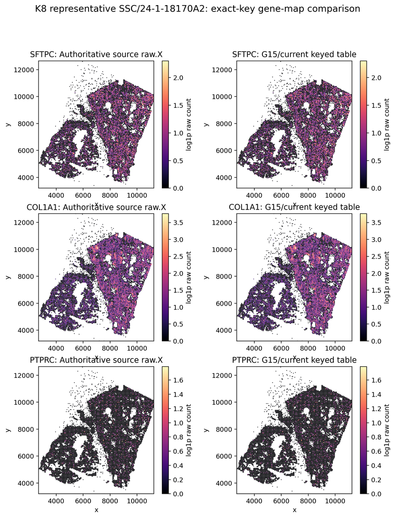

### J2 source-versus-current gene maps and orientation

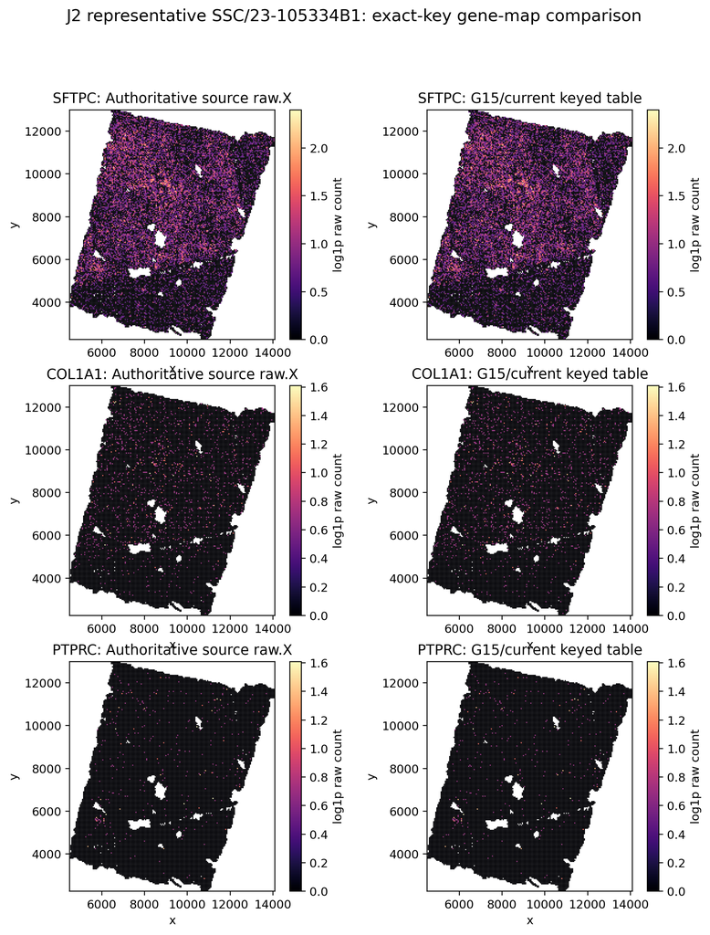

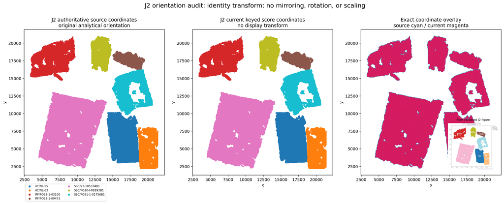

J2 uses the identity orientation: no mirror, rotation, scaling, or affine transform was applied. The current coordinates agree with the previously validated J2 tissue/mask orientation.

### L3 source-versus-current gene maps

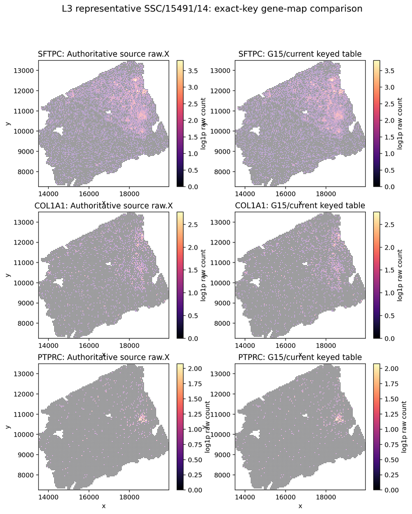

All gene-map comparisons use SFTPC, COL1A1, and PTPRC with identical coordinate limits, point sizes, and color scales between the authoritative source object and current keyed table.

## Output validation and provenance

```r
validation_table <- data.frame(
  check = names(validation),
  value = unlist(validation, use.names = FALSE)
)
knitr::kable(validation_table, format = "html")
```

| check | value |
| --- | --- |
| status | PASS |
| rook_metric_rows | 105 |
| paired_metric_rows | 105 |
| formal_patient_test_rows | 75 |
| adjacency_test_comparison_rows | 45 |
| program_summary_rows | 5 |
| all_coordinate_figures_present | TRUE |
| score_recomputed | FALSE |
| moran_recomputed_in_finalizer | FALSE |

```r
knitr::kable(provenance, format = "html")
```

| path | size_bytes | sha256 |
| --- | --- | --- |
| /mnt/d/bb/博士课题组资料/新建文件夹/自己课题相关/Lung ST/codex agent/stereo_seq/stereo_seq/results/reanalysis/bin50_all21_patient_pseudobulk_disease_signal_audit_260822/minimal_abundance_coordinate_qc_260822193323/04_a… | 6144414 | 0a446bff42ba24901276a7389b11424dbe4ec21a19e05fbadd90071ca6c35dee |
| /mnt/d/bb/博士课题组资料/新建文件夹/自己课题相关/Lung ST/codex agent/stereo_seq/stereo_seq/results/reanalysis/bin50_all21_patient_pseudobulk_disease_signal_audit_260822/frozen_leading_edge_spatial_mapping_pilot_2608221… | 27626 | 0bf84703ee82dc01208bc3db66c4e2bb66ddf87e3ed59e9b945cc9a81609eb9f |
| /mnt/d/bb/博士课题组资料/新建文件夹/自己课题相关/Lung ST/codex agent/stereo_seq/stereo_seq/results/reanalysis/bin50_all21_patient_pseudobulk_disease_signal_audit_260822/frozen_leading_edge_spatial_mapping_pilot_2608221… | 18237 | 1844c9aa0bcbc4651baa3daedd9b5a2689ecfc0f8b5a114f76be7dd26041c3b3 |
| /mnt/d/bb/博士课题组资料/新建文件夹/自己课题相关/Lung ST/codex agent/stereo_seq/stereo_seq/results/reanalysis/rctd_bcell_spatial_niche_analysis_260809035034/prepared_niche_inputs.h5 | 29450206 | 75815bbd67980001659afe5f242e7aea409c18e09384bdd9c836250742cc756b |
| /mnt/d/bb/博士课题组资料/新建文件夹/自己课题相关/Lung ST/codex agent/stereo_seq/stereo_seq/results/reanalysis/bin50_all21_patient_pseudobulk_disease_signal_audit_260822/minimal_abundance_coordinate_qc_260822193323/11_f… | 96 | 4027f4047ed1805669f6fab44318979c1a6da5a646b8f4c56001c382c0d88fde |

## Explicit next-analysis boundary

The next task is a separate visual registration audit between expression coordinates and ssDNA/H&E tissue images for K8, J2, and L3. It must assess rotation, mirroring, scaling, tissue-block mismatch, and local displacement. No new pathological partitioning, boundary-gradient analysis, or cell-neighbor analysis is allowed before that audit passes.